# week_04_pandas_viz_randomness

## CMPINF 2100 Week 04

### Use Pandas to help visualize the random simulation

We will use Pandas methods to visualize the random numbers generated in our simulation and their summary statistics.

## Import Modules

```python
import numpy as np
import pandas as pd
import matplotlib.pyplot as plt
```

## Generate random numbers

We need to initialize the random number generator object.

```python
rg = np.random.default_rng(2100)
```

Lets replicate generating 7 random numbers 25 times.

Assign the data to a 2D numpy array.

```python
x = rg.random((7,25))
```

```python
x.shape
```

```
(7, 25)
```

Lets convert the NumPy Array into a Pandas DataFrame.

```python
xdf = pd.DataFrame(x)
```

```python
xdf.info()
```

```
<class 'pandas.core.frame.DataFrame'>
RangeIndex: 7 entries, 0 to 6
Data columns (total 25 columns):
 #   Column  Non-Null Count  Dtype
---  ------  --------------  -----
 0   0       7 non-null      float64
 1   1       7 non-null      float64
 2   2       7 non-null      float64
 3   3       7 non-null      float64
 4   4       7 non-null      float64
 5   5       7 non-null      float64
 6   6       7 non-null      float64
 7   7       7 non-null      float64
 8   8       7 non-null      float64
 9   9       7 non-null      float64
```

[output cut: 17 more lines]

```python
xdf
```

|  | 0 | 1 | 2 | 3 | 4 | 5 | 6 | 7 | 8 | 9 | ... | 15 | 16 | 17 | 18 | 19 | 20 | 21 | 22 | 23 | 24 |
| --- | --- | --- | --- | --- | --- | --- | --- | --- | --- | --- | --- | --- | --- | --- | --- | --- | --- | --- | --- | --- | --- |
| 0 | 0.299037 | 0.948852 | 0.266548 | 0.562460 | 0.040653 | 0.362566 | 0.310743 | 0.021941 | 0.227507 | 0.446769 | ... | 0.669223 | 0.841995 | 0.323752 | 0.101129 | 0.477719 | 0.968343 | 0.613910 | 0.135589 | 0.212824 | 0.407869 |
| 1 | 0.140621 | 0.661987 | 0.717689 | 0.727011 | 0.858592 | 0.330807 | 0.352472 | 0.017342 | 0.203099 | 0.037879 | ... | 0.959715 | 0.344034 | 0.702449 | 0.494460 | 0.543104 | 0.517650 | 0.479081 | 0.059607 | 0.446262 | 0.334743 |
| 2 | 0.504814 | 0.980734 | 0.177619 | 0.521766 | 0.402251 | 0.041145 | 0.203472 | 0.473648 | 0.539202 | 0.002559 | ... | 0.307807 | 0.930980 | 0.542243 | 0.083027 | 0.006622 | 0.511821 | 0.156086 | 0.149384 | 0.790806 | 0.839081 |
| 3 | 0.445145 | 0.396780 | 0.455287 | 0.029069 | 0.754733 | 0.658180 | 0.028312 | 0.644796 | 0.357419 | 0.267659 | ... | 0.415794 | 0.774862 | 0.320069 | 0.143714 | 0.233343 | 0.667261 | 0.512088 | 0.536866 | 0.006084 | 0.060231 |
| 4 | 0.319739 | 0.567626 | 0.389765 | 0.181006 | 0.058185 | 0.205025 | 0.242565 | 0.171797 | 0.587954 | 0.402204 | ... | 0.428220 | 0.098465 | 0.208184 | 0.751207 | 0.023064 | 0.369426 | 0.201057 | 0.222495 | 0.890561 | 0.813590 |
| 5 | 0.351708 | 0.406931 | 0.525787 | 0.497786 | 0.395808 | 0.745044 | 0.228118 | 0.345135 | 0.860829 | 0.445399 | ... | 0.325963 | 0.533450 | 0.370350 | 0.531471 | 0.337524 | 0.517265 | 0.736357 | 0.541719 | 0.001432 | 0.122851 |
| 6 | 0.252510 | 0.625905 | 0.720810 | 0.787546 | 0.845918 | 0.461911 | 0.711858 | 0.648631 | 0.870721 | 0.519543 | ... | 0.709971 | 0.048651 | 0.099627 | 0.914454 | 0.207777 | 0.765200 | 0.912604 | 0.731434 | 0.917978 | 0.831390 |

7 rows × 25 columns

```python
xdf.describe()
```

|  | 0 | 1 | 2 | 3 | 4 | 5 | 6 | 7 | 8 | 9 | ... | 15 | 16 | 17 | 18 | 19 | 20 | 21 | 22 | 23 | 24 |
| --- | --- | --- | --- | --- | --- | --- | --- | --- | --- | --- | --- | --- | --- | --- | --- | --- | --- | --- | --- | --- | --- |
| count | 7.000000 | 7.000000 | 7.000000 | 7.000000 | 7.000000 | 7.000000 | 7.000000 | 7.000000 | 7.000000 | 7.000000 | ... | 7.000000 | 7.000000 | 7.000000 | 7.000000 | 7.000000 | 7.000000 | 7.000000 | 7.000000 | 7.000000 | 7.000000 |
| mean | 0.330511 | 0.655545 | 0.464786 | 0.472378 | 0.479449 | 0.400668 | 0.296792 | 0.331899 | 0.520962 | 0.303144 | ... | 0.545242 | 0.510348 | 0.366668 | 0.431352 | 0.261308 | 0.616710 | 0.515883 | 0.339585 | 0.466564 | 0.487108 |
| std | 0.120569 | 0.234235 | 0.208451 | 0.275919 | 0.350426 | 0.245806 | 0.209770 | 0.270538 | 0.275850 | 0.207959 | ... | 0.241248 | 0.357746 | 0.201672 | 0.332369 | 0.207093 | 0.200043 | 0.272502 | 0.259234 | 0.404530 | 0.339952 |
| min | 0.140621 | 0.396780 | 0.177619 | 0.029069 | 0.040653 | 0.041145 | 0.028312 | 0.017342 | 0.203099 | 0.002559 | ... | 0.307807 | 0.048651 | 0.099627 | 0.083027 | 0.006622 | 0.369426 | 0.156086 | 0.059607 | 0.001432 | 0.060231 |
| 25% | 0.275774 | 0.487278 | 0.328157 | 0.339396 | 0.226996 | 0.267916 | 0.215795 | 0.096869 | 0.292463 | 0.152769 | ... | 0.370878 | 0.221249 | 0.264127 | 0.122421 | 0.115421 | 0.514543 | 0.340069 | 0.142486 | 0.109454 | 0.228797 |
| 50% | 0.319739 | 0.625905 | 0.455287 | 0.521766 | 0.402251 | 0.362566 | 0.242565 | 0.345135 | 0.539202 | 0.402204 | ... | 0.428220 | 0.533450 | 0.323752 | 0.494460 | 0.233343 | 0.517650 | 0.512088 | 0.222495 | 0.446262 | 0.407869 |
| 75% | 0.398427 | 0.805420 | 0.621738 | 0.644736 | 0.800325 | 0.560046 | 0.331608 | 0.559222 | 0.724391 | 0.446084 | ... | 0.689597 | 0.808429 | 0.456297 | 0.641339 | 0.407622 | 0.716230 | 0.675133 | 0.539292 | 0.840683 | 0.822490 |
| max | 0.504814 | 0.980734 | 0.720810 | 0.787546 | 0.858592 | 0.745044 | 0.711858 | 0.648631 | 0.870721 | 0.519543 | ... | 0.959715 | 0.930980 | 0.702449 | 0.914454 | 0.543104 | 0.968343 | 0.912604 | 0.731434 | 0.917978 | 0.839081 |

8 rows × 25 columns

```python
x.mean(axis=0)
```

```
array([0.33051069, 0.65554494, 0.4647863 , 0.47237767, 0.47944854,
       0.40066837, 0.29679165, 0.3318987 , 0.52096157, 0.30314448,
       0.47344375, 0.46069332, 0.53912547, 0.5634313 , 0.44361449,
       0.54524158, 0.51034817, 0.36666782, 0.43135169, 0.26130762,
       0.61670956, 0.51588311, 0.33958488, 0.46656396, 0.48710793])
```

```python
xdf.describe().index
```

```
Index(['count', 'mean', 'std', 'min', '25%', '50%', '75%', 'max'], dtype='object')
```

```python
xdf.describe().loc[["mean", "std"]]
```

|  | 0 | 1 | 2 | 3 | 4 | 5 | 6 | 7 | 8 | 9 | ... | 15 | 16 | 17 | 18 | 19 | 20 | 21 | 22 | 23 | 24 |
| --- | --- | --- | --- | --- | --- | --- | --- | --- | --- | --- | --- | --- | --- | --- | --- | --- | --- | --- | --- | --- | --- |
| mean | 0.330511 | 0.655545 | 0.464786 | 0.472378 | 0.479449 | 0.400668 | 0.296792 | 0.331899 | 0.520962 | 0.303144 | ... | 0.545242 | 0.510348 | 0.366668 | 0.431352 | 0.261308 | 0.616710 | 0.515883 | 0.339585 | 0.466564 | 0.487108 |
| std | 0.120569 | 0.234235 | 0.208451 | 0.275919 | 0.350426 | 0.245806 | 0.209770 | 0.270538 | 0.275850 | 0.207959 | ... | 0.241248 | 0.357746 | 0.201672 | 0.332369 | 0.207093 | 0.200043 | 0.272502 | 0.259234 | 0.404530 | 0.339952 |

2 rows × 25 columns

## Visualization

Boxplot can help visualize the CENTRAL behavior AND the variation of COLUMNS in DataFrames!

Let's use a boxplot now to understand the variability in the samples across the REPLICATIONS.

Please remember, the COLUMNS in `xdf` are REPLICATIONS of generating 7 random numbers!

```
<function matplotlib.pyplot.show(close=None, block=None)>
```

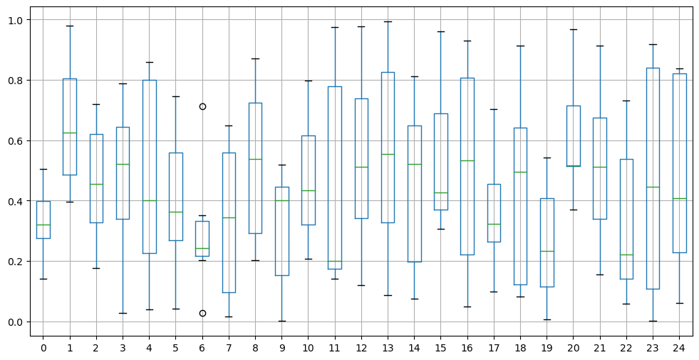

```python
fig, ax = plt.subplots(figsize=(12,6))
xdf.boxplot(ax=ax)
plt.show
```

But the horiznal green line is NOT the AVERAGE.

Lets include the AVG in the boxplot!

```
<function matplotlib.pyplot.show(close=None, block=None)>
```

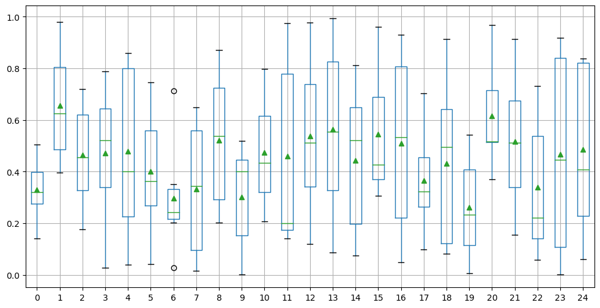

```python
fig, ax = plt.subplots(figsize=(12,6))
xdf.boxplot(ax=ax, showmeans=True)
plt.show
```

Let's change the green triangle to a red triangle.

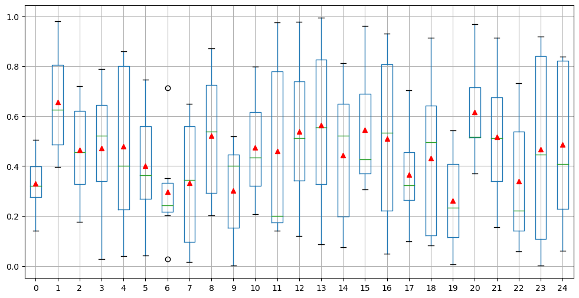

```python
fig, ax = plt.subplots(figsize=(12,6))
xdf.boxplot(ax=ax, showmeans=True, meanprops={"markerfacecolor": "red", "markeredgecolor":"red"})
plt.show()
```

But we use far more than just 25 replications in our simulations.

We saw that when thousands of reps were used the SIMULATION bheaved like theory.

The CLT showed the reps thousands of times produced a GAUSSIAN or BELL CURVE distribution for the avgs!

Let's now use 500 reps to see the variation in the sample avg based on 7 random samples.

```python
rg = np.random.default_rng(2100)
```

```python
xdf_more_reps = pd.DataFrame(rg.random((7, 500)))
```

```python
xdf_more_reps
```

|  | 0 | 1 | 2 | 3 | 4 | 5 | 6 | 7 | 8 | 9 | ... | 490 | 491 | 492 | 493 | 494 | 495 | 496 | 497 | 498 | 499 |
| --- | --- | --- | --- | --- | --- | --- | --- | --- | --- | --- | --- | --- | --- | --- | --- | --- | --- | --- | --- | --- | --- |
| 0 | 0.299037 | 0.948852 | 0.266548 | 0.562460 | 0.040653 | 0.362566 | 0.310743 | 0.021941 | 0.227507 | 0.446769 | ... | 0.509911 | 0.422425 | 0.749973 | 0.120535 | 0.041217 | 0.460483 | 0.594597 | 0.490814 | 0.937329 | 0.990414 |
| 1 | 0.930755 | 0.623563 | 0.747365 | 0.168700 | 0.293281 | 0.498456 | 0.392393 | 0.958350 | 0.431861 | 0.784673 | ... | 0.068779 | 0.892515 | 0.653912 | 0.761983 | 0.586735 | 0.358874 | 0.201725 | 0.266203 | 0.672838 | 0.481577 |
| 2 | 0.199215 | 0.588934 | 0.507333 | 0.390698 | 0.611772 | 0.946904 | 0.208789 | 0.871133 | 0.433285 | 0.977843 | ... | 0.265850 | 0.024705 | 0.073870 | 0.501902 | 0.374664 | 0.532983 | 0.262035 | 0.363750 | 0.717184 | 0.414940 |
| 3 | 0.766334 | 0.833758 | 0.471069 | 0.098592 | 0.569948 | 0.573934 | 0.674496 | 0.144761 | 0.475206 | 0.176684 | ... | 0.977885 | 0.057759 | 0.357068 | 0.935469 | 0.546936 | 0.453331 | 0.512838 | 0.300627 | 0.878900 | 0.388745 |
| 4 | 0.800868 | 0.658872 | 0.801847 | 0.026681 | 0.404485 | 0.677714 | 0.569030 | 0.798018 | 0.639441 | 0.180423 | ... | 0.362680 | 0.045245 | 0.807969 | 0.015788 | 0.664524 | 0.804680 | 0.181803 | 0.778175 | 0.365610 | 0.590861 |
| 5 | 0.901608 | 0.988555 | 0.587119 | 0.648128 | 0.570799 | 0.859823 | 0.738553 | 0.474729 | 0.392026 | 0.517895 | ... | 0.811841 | 0.031269 | 0.240247 | 0.055750 | 0.604664 | 0.962763 | 0.624271 | 0.564095 | 0.898256 | 0.047328 |
| 6 | 0.987319 | 0.153878 | 0.412093 | 0.009818 | 0.587570 | 0.412670 | 0.879730 | 0.458669 | 0.070008 | 0.731612 | ... | 0.956072 | 0.444674 | 0.861676 | 0.056747 | 0.319836 | 0.650065 | 0.659859 | 0.389285 | 0.374476 | 0.429380 |

7 rows × 500 columns

```python
xdf_more_reps.shape
```

```
(7, 500)
```

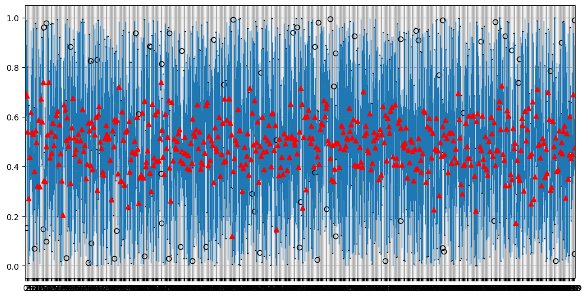

```python
fig, ax = plt.subplots(figsize=(12,6))
xdf_more_reps.boxplot(ax=ax, showmeans=True, meanprops={"markerfacecolor": "red", "markeredgecolor":"red"})
plt.show()
```

What happens if we use fewer random samples to calc the sample avg?

Lets generate 3 random samples and replication 500 times

```python
rg = np.random.default_rng(2100)
```

```python
x_N003_df = pd.DataFrame(rg.random((3, 500)))
```

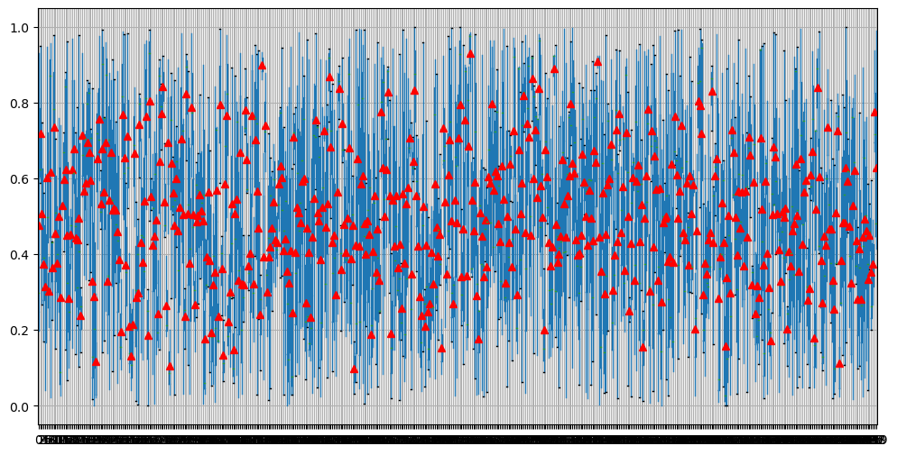

```python
fig, ax = plt.subplots(figsize=(12,6))
x_N003_df.boxplot(ax=ax, showmeans=True, meanprops={"markerfacecolor": "red", "markeredgecolor":"red"})
plt.show()
```

What if we generated many more samples per replication?

What if the sample avg was calculated on 700 random samples per replication?

```python
rg = np.random.default_rng(2100)
```

```python
x_N700_df = pd.DataFrame(rg.random((700, 500)))
```

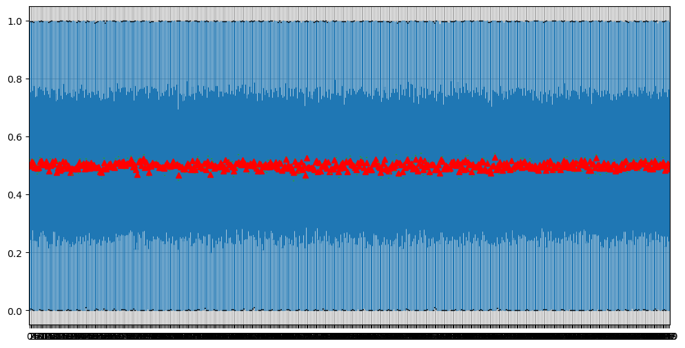

```python
fig, ax = plt.subplots(figsize=(12,6))
x_N700_df.boxplot(ax=ax, showmeans=True, meanprops={"markerfacecolor": "red", "markeredgecolor":"red"})
plt.show()
```

```python
x_N700_df.describe()
```

|  | 0 | 1 | 2 | 3 | 4 | 5 | 6 | 7 | 8 | 9 | ... | 490 | 491 | 492 | 493 | 494 | 495 | 496 | 497 | 498 | 499 |
| --- | --- | --- | --- | --- | --- | --- | --- | --- | --- | --- | --- | --- | --- | --- | --- | --- | --- | --- | --- | --- | --- |
| count | 700.000000 | 700.000000 | 700.000000 | 700.000000 | 700.000000 | 700.000000 | 700.000000 | 700.000000 | 700.000000 | 700.000000 | ... | 700.000000 | 700.000000 | 700.000000 | 700.000000 | 700.000000 | 700.000000 | 700.000000 | 700.000000 | 700.000000 | 700.000000 |
| mean | 0.502666 | 0.499209 | 0.515235 | 0.511138 | 0.494616 | 0.494265 | 0.491882 | 0.493278 | 0.514488 | 0.516395 | ... | 0.495534 | 0.500833 | 0.504856 | 0.500679 | 0.513369 | 0.501433 | 0.484305 | 0.499629 | 0.508106 | 0.487892 |
| std | 0.297542 | 0.286071 | 0.279486 | 0.292176 | 0.290104 | 0.286177 | 0.285187 | 0.300607 | 0.291046 | 0.290293 | ... | 0.281165 | 0.291955 | 0.288236 | 0.287639 | 0.296760 | 0.281035 | 0.298877 | 0.285886 | 0.289670 | 0.294626 |
| min | 0.001025 | 0.004724 | 0.001928 | 0.000327 | 0.000706 | 0.001061 | 0.000143 | 0.003504 | 0.001997 | 0.001393 | ... | 0.004989 | 0.002199 | 0.000675 | 0.003358 | 0.000013 | 0.002818 | 0.000244 | 0.003219 | 0.001611 | 0.000484 |
| 25% | 0.236883 | 0.246823 | 0.279964 | 0.244648 | 0.244000 | 0.240505 | 0.254675 | 0.221986 | 0.258290 | 0.272102 | ... | 0.264289 | 0.246167 | 0.239779 | 0.260701 | 0.258726 | 0.258454 | 0.221548 | 0.258287 | 0.254519 | 0.242274 |
| 50% | 0.522891 | 0.496935 | 0.506092 | 0.521897 | 0.496942 | 0.503209 | 0.471751 | 0.478639 | 0.529936 | 0.519515 | ... | 0.491983 | 0.515604 | 0.515069 | 0.491981 | 0.528960 | 0.489528 | 0.486678 | 0.506599 | 0.498400 | 0.497083 |
| 75% | 0.764921 | 0.753658 | 0.757300 | 0.774809 | 0.736201 | 0.727830 | 0.737752 | 0.768432 | 0.771937 | 0.763697 | ... | 0.729314 | 0.752740 | 0.745922 | 0.739246 | 0.766043 | 0.753807 | 0.751990 | 0.736181 | 0.762176 | 0.733853 |
| max | 0.998928 | 0.998971 | 0.998305 | 0.996532 | 0.998774 | 0.998426 | 0.998044 | 0.999923 | 0.998978 | 0.999904 | ... | 0.990224 | 0.999381 | 0.999355 | 0.998764 | 0.998892 | 0.997649 | 0.999679 | 0.998259 | 0.999870 | 0.995952 |

8 rows × 500 columns